# Who counts as a case

Class

Author

Joshua Loftus

## How this sheet works

Exercises rederive or apply the lecture’s results. Do them on your own time; they are not worked in class. The class works the discussions, the problems and the coding under “In class,” in that order. Discussions are in groups of three or four, then with the room. Each problem, and the coding, is gone through as soon as the room has tried it.

Every item is about one decision: who is in the data, what is recorded about them, and what to do about the people and the columns that are not there. Someone made that decision, usually not the people left out, and every way of handling what is missing is an assumption about people nobody asked. So each item ends by asking who the mistake falls on, who gains from it going unnoticed, or who the choice could be justified to. The arithmetic is how you earn an answer to that question; it is not the answer.

Notation as in the lecture: $C = 1$ if a person’s $Y$ is recorded and $C = 0$ if it is missing; $e(X) = P(C = 1 \mid X)$; $A$ is a group. A subscript on an expectation names the random variables it averages over: $E_X\big[E_Y[Y \mid X]\big]$ averages $Y$ among the people with each value of $X$, then averages those means over $X$. An expectation with no subscript averages over everything random inside it.

## Exercises

Attempt each part before you open a hint.

**WarningHints**

Do not open a hint unless you have been stuck for at least a few minutes, and open them in order.

### Exercise 1. Selection on a collider, by hand

A company’s records cover the people it hired. It hired every applicant who either did well at the interview or had a referral from a current employee. Among applicants, half did well at the interview and half had a referral, independently of each other.

1. Among the people hired, what fraction of those with a referral did well at the interview? What fraction of those without a referral?
2. Draw the causal graph with three nodes: interview, referral, hired. Which node do the company’s records condition on?
3. The company notices that referred hires did worse at interview than other hires, concludes that referrals attract weaker candidates, and raises the interview bar for referred applicants. What is wrong with the conclusion, and who pays for it?
4. Redo (a) when a fraction $q$ of applicants do well at the interview, whatever $q$ is. Does the gap between the two fractions depend on $q$?

**TipHint 1**

Start with the hires who have no referral. How did each of them get in?

**TipHint 2**

Among the applicants with a referral, the hiring rule kept everyone.

**NoteSolution**

1. Everyone without a referral was hired only because they did well at the interview, so that fraction is $1$. Those with a referral were hired whatever their interview, so among them the interview fraction is the applicants’ fraction, $1/2$.
2. interview $\to$ hired $\leftarrow$ referral. The records condition on hired $= 1$, a collider.
3. In the applicant pool the two are unrelated. The negative association among hires was created by the hiring rule: a referred hire did not need a good interview to get in, and an unreferred hire did. Nothing about referrals and the quality of candidates follows. The people who pay are the next referred applicants, held to a higher bar because of a pattern the company’s own rule produced. The records describe the rule, not the candidates.
4. With a referral: $q$. Without: $1$. The gap is $1 - q$, so it depends on $q$, and it is zero only if everyone does well at the interview.

### Exercise 2. The unaware model, with a smaller coaching effect

Leaving a protected characteristic out of a model is often done in the name of fairness. This exercise computes what it buys, in the lecture’s model with a smaller coaching effect.

Job performance $Y \sim N(0, 1)$, larger is better. A group $A \in \{0, 1\}$, half the population each, independent of $Y$. A test score $X = Y + A + \varepsilon$ with $\varepsilon \sim N(0, 1)$ independent of both: group 1 gets one point from coaching, and nothing else. (The lecture had two points, $\beta_A = 2$; here $\beta_A = 1$.)

1. Compute $E[X]$, $\operatorname{Var}(X)$ and $\operatorname{Cov}(X, Y)$. The *unaware* model is the regression of $Y$ on $X$: give its prediction $\hat Y$ as a function of $X$, and the average prediction in each group.
2. The *full* model uses $X$ and $A$. Within group $a$, $X - a = Y + \varepsilon$. Give the full model’s prediction, the coefficient on $A$, and the average prediction in each group.
3. Compute the mean squared error of each model. Which is more accurate, and which predicts a bigger gap between the groups?
4. Someone reads the coefficient on $A$ in (b) as the effect of group membership on job performance. What is wrong with that reading? Which group does each of the two mistakes, the unaware model’s gap and this reading, fall on?

**TipHint 1**

The slope of a simple regression is covariance over variance, and the line passes through the point of means.

**TipHint 2**

For (c), the mean squared error of the regression of $Y$ on $X$ is $\operatorname{Var}(Y) - \operatorname{Cov}(X, Y)^2/\operatorname{Var}(X)$.

**NoteSolution**

1. $E[X] = E[Y] + E[A] = 1/2$. $\operatorname{Var}(A) = 1/4$, so $\operatorname{Var}(X) = 1 + 1/4 + 1 = 9/4$. $A$ and $\varepsilon$ are independent of $Y$, so $\operatorname{Cov}(X, Y) = \operatorname{Var}(Y) = 1$. Slope $1/(9/4) = 4/9$, and the line passes through the means: $\hat Y = \tfrac49 (X - \tfrac12)$. In group 0, $E[X] = 0$, average prediction $-2/9$. In group 1, $E[X] = 1$, average prediction $+2/9$.
2. Within group $a$, regress $Y$ on $X - a = Y + \varepsilon$: slope $1/(1 + 1) = 1/2$, so $\hat Y = \tfrac12 (X - A) = \tfrac12 X - \tfrac12 A$. The coefficient on $A$ is $-1/2$. Average prediction $\tfrac12 E[Y] = 0$ in each group.
3. Unaware: $\operatorname{Var}(Y) - \operatorname{Cov}(X, Y)^2/\operatorname{Var}(X) = 1 - 4/9 = 5/9$. Full: $1 - 1/2 = 1/2$ in each group. The full model is more accurate, and it predicts no gap. The unaware model predicts a gap of $4/9$ of a standard deviation where there is none.
4. The coefficient is a statement about prediction among people with the same score: at a given score, group 1 does worse, because part of its score came from coaching. Changing someone’s group would not change their $Y$ at all. $X$ is a collider between $A$ and $Y$, and conditioning on it created the association. The comparison of group means, which does not condition on $X$, gives the right answer, $0$. The two mistakes fall on different groups. The unaware model’s gap favors the coached group and costs the uncoached one, by $4/9$ of a standard deviation in the average prediction. The causal reading of the coefficient says the coached group is worse at the job, which is false. Neither is a fact about the people; both are facts about what was done with the data.

### Exercise 3. Inverse probability weighting

$X$ is always recorded and $Y$ is sometimes missing; $C = 1$ when it is recorded, and $e(X) = P(C = 1 \mid X) > 0$ for every value of $X$.

1. Show that under MAR, $E\!\left[\dfrac{C\,Y}{e(X)}\right] = E[Y]$. Say where MAR is used, and where the condition $e(X) > 0$ is used.
2. In the lecture’s income example, $X$ is age (young or old, half each), the young earn 40 on average and answer with probability 0.8, the old earn 60 on average and answer with probability 0.4. Compute the weighted mean and compare it with the mean of the recorded incomes, 46.7.
3. In practice $e(X)$ is not known. Say in one sentence how you would estimate it from the data, and what the estimate uses that the complete-case mean throws away.
4. The weighted mean assumes that the old people who did not answer earn what the old people who did answer earn. The complete-case mean assumes something too: say what. Which assumption would you rather defend to the people who did not answer, and what would it take to check either?

**TipHint 1**

Condition on $X$ first: $E[CY/e(X)] = E_X\big[E_{C,Y}[CY \mid X]/e(X)\big]$.

**TipHint 2**

Under MAR, $C$ and $Y$ are independent given $X$, so $E_{C,Y}[CY \mid X] = E_C[C \mid X]\,E_Y[Y \mid X]$.

**NoteSolution**

1. Write $Z = CY/e(X)$. The law of total expectation says $E[Z] = E_X\big[E_{C,Y}[Z \mid X]\big]$: average $Z$ among the people who share each value of $X$, then average those conditional means over the distribution of $X$. Inside the inner expectation $X$ is held fixed, so $e(X)$ is a fixed number there, and a fixed number comes out of an expectation: $E_{C,Y}[CY/e(X) \mid X] = E_{C,Y}[CY \mid X]/e(X)$. This is the step that needs the response probability to depend on $X$ alone. If it depended on $Y$ too, it would still vary at fixed $X$ and could not be taken out. MAR says $C$ is independent of $Y$ given $X$, so $E_{C,Y}[CY \mid X] = E_C[C \mid X]\,E_Y[Y \mid X] = e(X)\,E_Y[Y \mid X]$. Dividing by $e(X)$ needs $e(X) > 0$: a group nobody answers in cannot be reweighted. What is left is $E_X\big[E_Y[Y \mid X]\big] = E[Y]$, the law of total expectation again.
2. $\tfrac12(0.8)(40)/0.8 + \tfrac12(0.4)(60)/0.4 = 20 + 30 = 50$, the true mean. The recorded incomes average $46.7$ because the young, who earn less, answer more often.
3. Regress the indicator $C$ on $X$ (a logistic regression, or the share answering at each value of $X$), and use the fitted probabilities as $e(X)$. The estimate uses the rows where $Y$ is missing: their $X$ is recorded, and it is what tells you who did not answer.
4. The complete-case mean assumes that the people who did not answer earn what the people who did answer earn, whatever their age: MCAR. The recorded data already contradict it, since response differs by age. The weights assume MAR given age, which the recorded data can neither confirm nor refute: within an age group, nothing recorded says whether the silent earn more or less than the rest. Checking either would mean asking some of the people who did not answer, that is, collecting what was not collected. The weights do not escape the assumption; they write it down. The complete-case mean rests on an assumption too, and nobody wrote it down. A written assumption can be challenged by the people it is about, and an unwritten one cannot.

## In class

### Discussion 1: who is missing from the data you brought

Use the dataset or study you brought, where some people who should be in it are not. If you did not bring one, choose: a customer satisfaction survey; a hospital’s records of patient outcomes; a university’s record of its graduates’ salaries; the crimes recorded by the police; a dating app’s record of which matches led to a date.

1. Who is missing, and which way does their absence push the result? Who is better off for that?
2. Relative to what the dataset records about people, is the missingness closer to completely at random, at random, or not at random? What would the dataset have to record to make it “at random”?
3. Name one dataset that should exist and does not. Who would have had to collect it, and why have they not?

**NoteSome examples**

- A satisfaction survey: the people who left are not there to be asked, and the furious and the delighted answer more than the middle. Which direction depends on the mix; the spread is too wide and the mean is pulled toward whichever end answers more. The firm that reports the score is better off whenever the people who left were the unhappy ones. Nothing recorded about the people who left makes it MAR; a record of who was invited, with what they had bought, would help.
- Graduates’ salaries: people who did not find work, or did not want to say, do not answer, so the mean is too high, and the university that prints it in its prospectus is better off. MNAR, since the salary itself drives the answer. Recording employment status for everyone, from a separate source, would move it toward MAR.
- Recorded crime: crimes nobody reported and places nobody patrolled. The direction depends on the crime; the record is too high where the police look, and the people who live there pay for it in the next round of patrols.
- A dataset that should exist: the lecture’s own case, how often detained defendants would have returned to court; or deaths in custody, counted by the institution that held the person; or the wages of people paid in cash. The institution that would have to collect it is often the one the data would judge.

### Problem 1. Why is it missing, and which way?

1. For each setting, say whether the missing values are MCAR, MAR or MNAR, and whether the mean of the recorded values is too high, too low, or neither, compared with the mean for everyone. Say which clause of the setting your answer depends on, and who is worse off if the recorded mean is taken at face value.
- A fitness watch records resting heart rate only on nights it is worn. People take it off on nights they feel unwell, and nothing else about them is recorded.
- Exam marks are missing for students whose exam scripts were lost in the post; the post lost one sack at random.
- A survey asks about weekly hours worked, and the overall mean will set one staffing standard for both regions. Response is lower in one region than another, the region is recorded, and within each region whether someone responds is unrelated to their hours.
2. A company surveys its staff about pay. Half are junior, with mean salary 30 (thousands), and half are senior, with mean salary 70. Juniors respond with probability 0.9 and seniors with probability 0.3. Within each grade, whether someone responds is unrelated to their salary. What is the true mean salary? What is the mean among respondents? Check your answer with $E[Y \mid C = 1] - E[Y] = \operatorname{Cov}(Y, C)/P(C = 1)$.
3. Weight each respondent by one over their grade’s response probability. Show that the weighted mean recovers the true mean. (For 100 staff: how many respondents are in each grade, and what weight does each get?)
4. Now suppose that within each grade the better-paid staff respond less often. Is the weighted mean from (c) still right? Which way is it wrong, and what would fix it? Who would have to agree to the fix?

**TipHint 1**

For (b): $E[YC]$ is the average over everyone of salary times the response indicator, so sum salary times response probability over the two grades, each with weight $1/2$.

**TipHint 2**

For (c): of 100 staff, 50 are junior and 45 of them respond.

**NoteSolution**

1. The watch: MNAR. Whether a night is recorded depends on feeling unwell, which is related to heart rate and is not recorded; the clause “nothing else about them is recorded” is what rules out MAR. Recorded nights are healthier nights, so the mean resting heart rate is too low, and the wearer is worse off: the nights a doctor would want to see are the ones not there. Lost scripts: MCAR, because the sack was lost at random; without that clause (if the post lost the sack from one school) it need not be. The mean is unbiased, just based on fewer students; nobody is misled by it, though the students whose scripts were lost have a different problem. Hours by region: MAR given region, and the clause “within each region … unrelated to their hours” is doing the work. The overall mean is biased toward the region that responds more, in the direction of that region’s mean, so the standard is set closer to the hours of the region that answered more, and the other region works to a number that is mostly not its own.
2. True mean $\tfrac12(30) + \tfrac12(70) = 50$. $P(C = 1) = \tfrac12(0.9) + \tfrac12(0.3) = 0.6$. $E[YC] = \tfrac12(0.9)(30) + \tfrac12(0.3)(70) = 13.5 + 10.5 = 24$, so the respondents’ mean is $24/0.6 = 40$, too low by 10. Check: $\operatorname{Cov}(Y, C) = 24 - 50 \times 0.6 = -6$, and $-6/0.6 = -10$.
3. Of 100 staff, 45 juniors and 15 seniors respond. Juniors get weight $1/0.9$, seniors $1/0.3$. Weighted mean $(45 \times 30/0.9 + 15 \times 70/0.3)/100 = (1500 + 3500)/100 = 50$. In general $E[CY/e(X)] = E[Y]$ when response depends only on the recorded grade $X$, with $e(X) = P(C = 1 \mid X)$ (exercise 3).
4. No. Missingness now depends on salary within grade, which is MNAR. The weights correct for the difference between grades but not within them: within each grade the respondents are the lower paid, so the weighted mean is still too low. Nothing computed from the recorded salaries fixes it; what would is a recorded variable that explains who answers within a grade (a pay band from the payroll, say), or an assumption about the non-respondents that someone is prepared to defend. The payroll fix uses data the staff gave for another purpose, so the staff, or whoever speaks for them, would have to agree to it. The assumption fix needs no one’s agreement, which is why it has to be written down and defended rather than made in private.

### Discussion 2: why leave out $A$?

In the lecture’s test-score example, the model that leaves the group $A$ out is less accurate in both groups and predicts a gap between groups whose $Y$ has the same distribution.

1. Write the strongest argument for leaving $A$ out, and the strongest argument against. Then say which causal graph each argument assumes.
2. Now $A$ is not a protected characteristic but a column that was recorded for half the applicants. Would you drop the column, drop the rows that lack it, or fill it in? Who would you have to justify the choice to, and could you?

**NoteSome directions**

1. For leaving it out: a model that uses $A$ gives two people with the same score different predictions because of their group, which is the shape of direct discrimination (Equality Act 2010, section 13), and if $A$ had shaped the recorded outcome itself, a model using $A$ would learn and repeat that; this assumes a graph with an arrow from $A$ into $Y$ or into how $Y$ was measured. Against: in the lecture’s graph $A$ affects the score and not the outcome, so leaving it out makes the model read coaching as ability, less accurate for everyone and worse for the group without coaching; a rule applied to all that disadvantages one group is the shape of indirect discrimination (section 19), unless justified. Neither argument works in the other’s graph, and the data do not say which graph holds.
2. The lecture’s table: dropping the column loses accuracy and creates the gap for everyone; dropping the rows keeps a correct model for the people who have $A$ and no prediction for the rest; filling in recovers the fit but, for a row without $A$, predicts from $X$ alone and keeps the gap. The question is who the model is for. The justification goes to whoever is scored by it, and to whoever asks later why a column is absent; “the software dropped it” is not an answer anyone can defend, and the point of the exercise is that it is the most common one.

### Coding 1: what a single fill-in does

You need `ggplot2` and, for coding 2, `mice` (`install.packages("mice")` once). $Y$ depends on $X$. Half the values of $Y$ are removed completely at random, so the complete cases are right about everything, and then each hole is filled once: with the recorded mean, and with the prediction from $X$.

```r
library(ggplot2)
n <- 500
X <- rnorm(n)
Y <- 1 + X + rnorm(n)                  # the truth: slope 1, sd(Y) = sqrt(2), cor(X, Y) = 1/sqrt(2)
C <- rbinom(n, 1, 0.5)                 # 1 if Y is recorded, 0 if it is missing: MCAR
d <- data.frame(X = X, Y = ifelse(C, Y, NA))
mean_imp <- ifelse(C, Y, mean(d$Y, na.rm = TRUE))     # every hole gets the recorded mean
reg_imp  <- # ...                                      # every hole gets the prediction from X
pic <- rbind(data.frame(X, Y = Y,        how = "all the data",          missing = C == 0),
             data.frame(X, Y = mean_imp, how = "mean imputation",       missing = C == 0),
             data.frame(X, Y = reg_imp,  how = "regression imputation", missing = C == 0))
ggplot(pic, aes(X, Y, color = missing)) + geom_point(alpha = 0.6) + facet_wrap(~ how) +
  scale_color_manual(values = c("gray50", "#BCAF6F"), labels = c("recorded", "missing"), name = NULL)
summaries <- function(y, x = X) c(sd = sd(y), cor = cor(x, y),
                                  slope = unname(coef(lm(y ~ x))[2]), q90 = unname(quantile(y, 0.9)))
round(rbind(`all the data` = summaries(Y), `complete cases` = summaries(Y[C == 1], X[C == 1]),
            `mean imputation` = summaries(mean_imp), `regression imputation` = summaries(reg_imp)), 2)
```

1. Complete the regression-imputation line: fit `lm(Y ~ X, data = d)`, which uses the rows that have $Y$, and give each hole its fitted value. Run everything. In each panel the gold points are the rows whose $Y$ went missing: on the left where they really are, in the other two where the fill-in put them. Say where they sit.
2. Read the table against the truth: $\operatorname{sd}(Y) = \sqrt2 \approx 1.41$, correlation $1/\sqrt2 \approx 0.71$, slope $1$, 90th percentile about $2.81$. Which quantities does each fill-in get wrong, and which way? The missingness is completely at random, so what does filling in add here?
3. Regression imputation gets the slope right and the correlation wrong. Say why, one sentence each.
4. The filled-in rows are people who were not asked, drawn as if they had answered exactly as predicted. Who is better off when a dataset looks more certain than it is, and who finds out?

**TipHint 1**

For step 1: `reg_imp <- ifelse(C, Y, predict(lm(Y ~ X, data = d), newdata = d))`.

**TipHint 2**

For step 3: the slope is $\operatorname{Cov}(X, Y)/\operatorname{Var}(X)$; the correlation divides by the spread of $Y$ as well.

**NoteSolution**

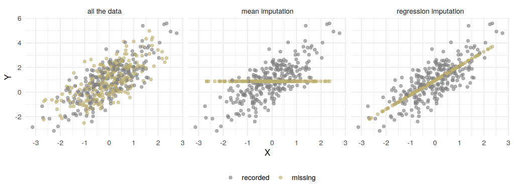

```r
n <- 500
X <- rnorm(n)
Y <- 1 + X + rnorm(n)
C <- rbinom(n, 1, 0.5)
d <- data.frame(X = X, Y = ifelse(C, Y, NA))
mean_imp <- ifelse(C, Y, mean(d$Y, na.rm = TRUE))
reg_imp  <- ifelse(C, Y, predict(lm(Y ~ X, data = d), newdata = d))
pic <- rbind(data.frame(X, Y = Y,        how = "all the data",          missing = C == 0),
             data.frame(X, Y = mean_imp, how = "mean imputation",       missing = C == 0),
             data.frame(X, Y = reg_imp,  how = "regression imputation", missing = C == 0))
ggplot(pic, aes(X, Y, color = missing)) + geom_point(alpha = 0.6) + facet_wrap(~ how) +
  scale_color_manual(values = c("gray50", "#BCAF6F"), labels = c("recorded", "missing"), name = NULL) +
  theme(legend.position = "bottom")
```

```r
summaries <- function(y, x = X) c(sd = sd(y), cor = cor(x, y),
                                  slope = unname(coef(lm(y ~ x))[2]), q90 = unname(quantile(y, 0.9)))
round(rbind(`all the data` = summaries(Y), `complete cases` = summaries(Y[C == 1], X[C == 1]),
            `mean imputation` = summaries(mean_imp), `regression imputation` = summaries(reg_imp)), 2)
```

```
                        sd  cor slope  q90
all the data          1.47 0.73  1.10 2.57
complete cases        1.53 0.76  1.17 2.56
mean imputation       1.10 0.56  0.63 2.04
regression imputation 1.35 0.85  1.17 2.46
```

1. Mean imputation puts every missing row on a horizontal line at the recorded mean, whatever its $X$. Regression imputation puts every missing row exactly on the fitted line, with no scatter around it. On the left the same rows are spread like everyone else.
2. Mean imputation: the standard deviation is too small (about $1.0$ in the population: half the points have no spread), the correlation and the slope are about half what they should be (the filled half has no relation to $X$, so the covariance halves while $\operatorname{Var}(X)$ does not: $0.5$ and $0.5$), and the 90th percentile is too low (about $2.19$: half the upper tail is gone). Regression imputation: the slope is right; the standard deviation is too small (about $1.22$: the filled half has the spread of the line, variance $1$, not of $Y$, variance $2$); the correlation is too high (about $0.82$: half the points sit exactly on the line); the 90th percentile is too low (about $2.54$). The complete cases are right about all four, up to sampling variation, because the rows went missing at random. Filling in adds $n/2$ invented values and the appearance of a larger, tidier dataset, and nothing else.
3. Slope: it is $\operatorname{Cov}(X, Y)/\operatorname{Var}(X)$, and a filled point on the line has the same covariance with $X$ as a real point does on average, so the covariance is unchanged and so is the slope. Correlation: it also divides by the standard deviation of $Y$, which the fill-in shrank, so it goes up; the filled points are perfectly predictable from $X$, and the correlation reports that as a fact about the world.
4. Directions. The analyst whose standard errors shrink and whose report looks precise; whoever wanted the number settled. Nobody finds out from the dataset, because the filled rows look like data. The people those rows stand for find out when a decision made on the “precise” number reaches them. Coding 2’s multiple imputation exists to keep the uncertainty about the people who were not asked inside the data: draws, not predictions.

### Coding 2: filling in, four ways

$Y$ depends on $X$ as in coding 1, and now values of $Y$ are removed in three ways; the mean of $Y$ is then estimated four ways. The regression-imputation line is the one you wrote in coding 1.

```r
library(mice)
n <- 2000
X <- rnorm(n)
Y <- 1 + X + rnorm(n)                       # the truth: E[Y] = 1, slope 1
C_mcar <- rbinom(n, 1, 0.5)                 # 1 if Y is recorded: with probability 1/2, whoever you are
C_mar  <- rbinom(n, 1, plogis(-1.5 * X))         # recorded less often when X is high (plogis is the logistic function)
C_mnar <- rbinom(n, 1, plogis(-1.5 * (Y - 1)))   # recorded less often when Y is high
c(mean(C_mcar), mean(C_mar), mean(C_mnar))

estimate <- function(C) {
  d <- data.frame(X = X, Y = ifelse(C, Y, NA))            # Y is NA where it is missing
  cc <- c(mean(d$Y, na.rm = TRUE), sd(d$Y, na.rm = TRUE) / sqrt(sum(C)))
  mean_imp <- ifelse(C, Y, mean(d$Y, na.rm = TRUE))        # fill the holes with the recorded mean
  mi <- c(mean(mean_imp), sd(mean_imp) / sqrt(n))
  reg_imp <- ifelse(C, Y, predict(lm(Y ~ X, data = d), newdata = d))   # fill the holes with the prediction from X
  ri <- c(mean(reg_imp), sd(reg_imp) / sqrt(n))
  imp <- mice(d, m = 20, method = "norm", printFlag = FALSE)   # 20 completions
  pooled <- summary(pool(with(imp, lm(Y ~ 1))))                # the mean of Y in each, pooled
  mult <- c(pooled$estimate, pooled$std.error)
  out <- rbind(`complete cases` = cc, `mean imputation` = mi,
               `regression imputation` = ri, `multiple imputation` = mult)
  colnames(out) <- c("estimate", "se")
  out
}
```

**TipHint 1**

For step 3: a standard error of the mean has the spread of the values on top and $\sqrt{n}$ underneath. Ask what each fill-in does to each.

**NoteSolution**

```r
set.seed(313)                      # so that these numbers do not depend on coding 1's draws
n <- 2000
X <- rnorm(n)
Y <- 1 + X + rnorm(n)
C_mcar <- rbinom(n, 1, 0.5)
C_mar  <- rbinom(n, 1, plogis(-1.5 * X))
C_mnar <- rbinom(n, 1, plogis(-1.5 * (Y - 1)))
estimate <- function(C) {
  d <- data.frame(X = X, Y = ifelse(C, Y, NA))
  cc <- c(mean(d$Y, na.rm = TRUE), sd(d$Y, na.rm = TRUE) / sqrt(sum(C)))
  mean_imp <- ifelse(C, Y, mean(d$Y, na.rm = TRUE))
  mi <- c(mean(mean_imp), sd(mean_imp) / sqrt(n))
  reg_imp <- ifelse(C, Y, predict(lm(Y ~ X, data = d), newdata = d))
  ri <- c(mean(reg_imp), sd(reg_imp) / sqrt(n))
  imp <- mice(d, m = 20, method = "norm", printFlag = FALSE)
  pooled <- summary(pool(with(imp, lm(Y ~ 1))))
  mult <- c(pooled$estimate, pooled$std.error)
  out <- rbind(`complete cases` = cc, `mean imputation` = mi,
               `regression imputation` = ri, `multiple imputation` = mult)
  colnames(out) <- c("estimate", "se")
  out
}
res <- list(MCAR = estimate(C_mcar), MAR = estimate(C_mar), MNAR = estimate(C_mnar))
side_by_side <- do.call(cbind, lapply(names(res), function(k) {
  m <- res[[k]]; colnames(m) <- paste(k, colnames(m)); m }))
round(side_by_side, 3)                                        # steps 2 and 3
```

```
                      MCAR estimate MCAR se MAR estimate MAR se MNAR estimate
complete cases                0.931   0.043        0.432  0.039         0.114
mean imputation               0.931   0.022        0.432  0.020         0.114
regression imputation         0.927   0.027        0.907  0.026         0.436
multiple imputation           0.926   0.040        0.913  0.040         0.430
                      MNAR se
complete cases          0.034
mean imputation         0.017
regression imputation   0.022
multiple imputation     0.034
```

```r
mean(Y)                                                       # this sample's full mean
```

```
[1] 0.9424195
```

```r
d <- data.frame(X = X, Y = ifelse(C_mar, Y, NA))              # step 4
imp <- mice(d, m = 20, method = "norm", printFlag = FALSE)
head(imp$imp$Y[, 1:4], 3)
```

```
           1          2           3         4
2  1.4019826  2.2402955 -0.08806483 1.5491798
3  1.1660330  1.6975809  1.31805297 0.8554692
4 -0.1018841 -0.1879142 -0.37539273 0.2665400
```

```r
pool(with(imp, lm(Y ~ 1)))$pooled[, c("estimate", "ubar", "b", "t", "m")]
```

```
   estimate         ubar           b           t  m
1 0.9008594 0.0009155531 0.001076484 0.002045861 20
```

### Problem 2. Selection on a collider, with numbers

A university admits by exam grade. Grades run from 1 to 10, each equally likely among applicants. Half the applicants come from a feeder school, independently of their grade. The pass mark is 7, and 5 for applicants from a feeder school. The university’s records cover admitted students only.

1. Among admitted students, what is the mean grade of those from a feeder school, and of those not from one?
2. Draw the causal graph with nodes grade, feeder school and admitted, and mark what the records condition on.
3. An analyst concludes from the records that feeder schools produce weaker students, and the university considers withdrawing the lower pass mark. What is wrong, and who would pay for the mistake?
4. Write down an admission rule under which, among the admitted, feeder-school students have the *higher* mean grade. What does this say about what the graph alone tells you, and about what the records are a record of?

**TipHint 1**

Among the admitted, which grades can a feeder-school student have, and which can a student from elsewhere have?

**TipHint 2**

For (d), make the feeder school’s bar the higher one.

**NoteSolution**

1. Admitted students not from a feeder school have grades 7 to 10, mean $8.5$. Admitted students from a feeder school have grades 5 to 10, mean $7.5$. The band 5 to 6 holds feeder-school students only.
2. grade $\to$ admitted $\leftarrow$ feeder school. The records condition on admitted $= 1$, a collider.
3. Among applicants, grade and school are unrelated: the mean grade is $5.5$ in both groups. The difference among the admitted was created by the rule, which let feeder-school applicants in on lower grades. Nothing about what feeder schools do to their students follows. “Produce” is a causal claim, and the records cannot support it. The mistake would fall on the next feeder-school applicants, who would lose the lower pass mark on the strength of a pattern that the lower pass mark itself produced.
4. A pass mark of 9 for feeder-school applicants and 7 for everyone else: means $9.5$ and $8.5$, the feeder-school students higher. The graph says that conditioning on the collider creates an association; the rule says which way. Without the rule, “depends on both” does not fix the sign (the lecture’s notes, after the noisy collider). The association among the admitted is a record of the university’s rule, a decision someone made and could change, and not of the students.

### Discussion 3: a label that exists only where a decision allowed it

A bank wants to know whether a new credit-scoring model would make better lending decisions than its current one. It evaluates the new model on its past applicants. It only knows whether an applicant repaid if it approved them.

1. Who is missing from the evaluation, and by what mechanism? Which way are the new model’s measured error rates likely to be wrong?
2. Who benefits from the problem going unnoticed?
3. The honest fix is to approve some applicants the current model rejects, chosen at random, and record what happens. Who pays for that, and is it justified?

**NoteSome directions**

1. The applicants the old model rejected: their repayment is not observed. If the old model rejected on things the new model also uses, the rejected are the ones expected to default, so the approved pool is safer than the applicant pool, and among them default is rare: MNAR by the decision the data are meant to evaluate (the lecture’s selective labels). The new model’s measured default rate among the people it would approve is too low, and its errors on people the old model rejected are invisible. If the old model rejected on things the new model does not use, the direction is not determined without more.
2. Whoever sells the new model, which looks better than it is; the bank, in the short run, which gets a number it can report; and nobody who was rejected, since their outcomes are the ones not counted. Lakkaraju and colleagues’ remedy, for judges, used the fact that decision-makers differ in leniency and cases are assigned to them at random; a bank with one policy has no lenient judge to compare with, which is why question 3’s fix is the one that does not rest on an assumption about the people rejected.
3. The bank pays, in the defaults among the randomly approved, and so do the randomly approved who default, since a loan one cannot repay is not a gift. The people who gain are the rejected applicants who would have repaid, who are exactly the people the current records cannot see, and every future applicant scored by a model whose errors were measured on everyone. Whether that is justified is a choice, and the two sides are not symmetric: the cost of the fix is visible and falls on the bank, the cost of not fixing it is invisible and falls on the people wrongly rejected. “We evaluate on the data we have” sounds neutral and is a decision in favor of the visible cost.

## For next time

Bring one rule or score that sorts people into two groups: admit or reject, flag or clear, treat or not. Write down the two ways it can be wrong, and who pays for each. One sentence each.

## References

- Lakkaraju, Himabindu, Jon Kleinberg, Jure Leskovec, Jens Ludwig and Sendhil Mullainathan, “The Selective Labels Problem: Evaluating Algorithmic Predictions in the Presence of Unobservables” (*Proceedings of the 23rd ACM SIGKDD International Conference on Knowledge Discovery and Data Mining*, 2017, 275–284), https://doi.org/10.1145/3097983.3098066.
- van Buuren, Stef, *Flexible Imputation of Missing Data*, second edition (Chapman and Hall/CRC, 2018), sections 1.3, 1.4, 2.3 and 3.1, https://stefvanbuuren.name/fimd/.
- Equality Act 2010 (c. 15), sections 13 and 19, https://www.legislation.gov.uk/ukpga/2010/15.